# CSCI E-63C Week 13 Problem Set

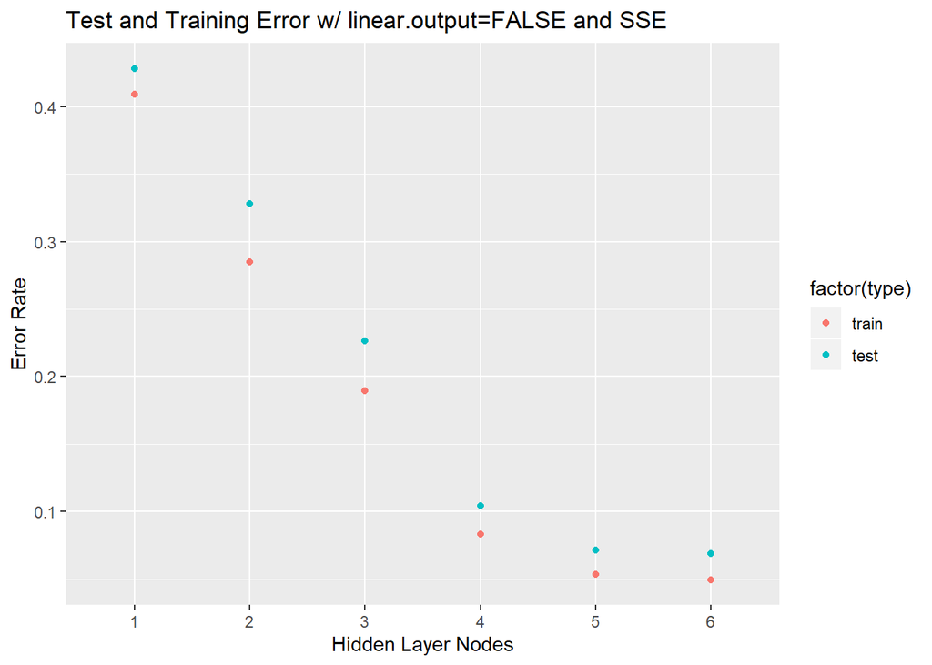

```r
# plot the errors for SSE error function and linear.output=FALSE
ggplot(net2,aes(x=factor(nodes),y=error, col=factor(type))) +
  geom_point() +
  labs(title = "Test and Training Error w/ linear.output=FALSE and SSE",
       x = "Hidden Layer Nodes",
       y = "Error Rate") +
  theme(legend.position = "right")
```

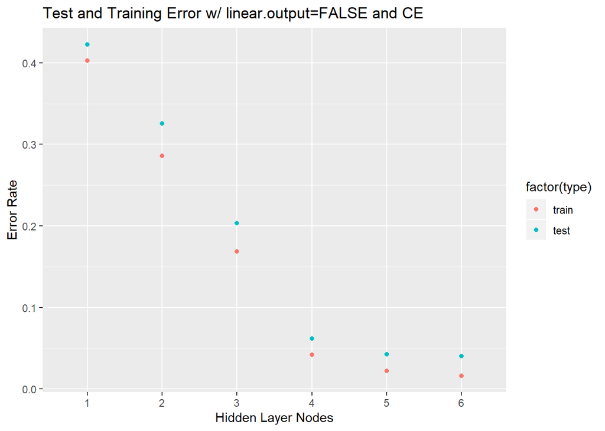

```r
# plot the errors for CE error function and linear.output=FALSE
ggplot(net3,aes(x=factor(nodes),y=error, col=factor(type))) +
  geom_point() +
  labs(title = "Test and Training Error w/ linear.output=FALSE and CE",
       x = "Hidden Layer Nodes",
       y = "Error Rate") +
  theme(legend.position = "right")
```

```r
test.errors <- cbind(net1[net1$type=="test",],net2[net2$type=="test",3],net3[net3$type=="test",3])
colnames(test.errors) <- c("type", "nodes", "error.net1", "error.net2", "error.net3")
test.errors
```

```
##    type nodes error.net1 error.net2 error.net3
## 7  test     1 0.42972626 0.42848485 0.42271919
## 8  test     2 0.32625556 0.32820606 0.32580606
## 9  test     3 0.22195455 0.22622727 0.20323838
## 10 test     4 0.13549899 0.10438687 0.06197677
## 11 test     5 0.09933737 0.07137879 0.04245556
## 12 test     6 0.09268889 0.06867374 0.04018990
```

From the above examples and scatterplots we see that once there are at least 4 nodes in the hidden layer a large portion of the error is reduced. Adding the 5th and 6th nodes continue to reduce the error rate however at a significantly smaller rate. The lowest test error rate for each type of output and error measurement occurs when the hidden layer has 6 nodes. 6 nodes would allow the data plotted in 3d to be encapsulted by 6 sided cube.

If you visualize our data in 3D space and select any 4 sides of a cube to encapsulate as much of the data as possible you can see that any open sides would make up a much smaller percentage of the data points that is the cube only had 3 or less sides. All 6 sides of the cube are necessary to achieve an optimal result however 4 sides (or 4 nodes for our model) captures a significant amount of the correct data points.

It’s important to note that the test error rate does not diverage from the training error rate. Both the test and training error continue to decrease from nodes 1 to 6 on all the plots. This indicates the model does not suffer from overfitting even a higher number of nodes.

The optimal combination of output type and error measurement is the cross-entropy error calculation method with a non-linear output. For all cases, it out performs the other options. Using the default parameters of a linear output and SSE calculation, we have the worst error rate performance, up from 4-5% from the optimal settings. For the next problem, I will only use the optimal model parameters of linear.output=FALSE and err.fct = “ce”.

# 5 Problem 3 (30 points): evaluate impacts of sample size and noise

Setup a simulation repeating procedure described above for n=100, 200 and 500 observations in the *training* set as well as adding none, 1, 2 and 5 null variables to the training and test data (and to the covariates in formula provided to `neuralnet`). Draw values for null variables from standard normal distribution as well and do not use them in the assignment of the observations to the class category (e.g. `x<-matrix(rnorm(600),ncol=6); cl<-as.numeric(factor(rowSums(abs(x[,1:3])<1.25)==3))` creates dataset with three informative and three null variables). Repeat calculation of training and test errors at least several times for each combination of sample size, number of null variables and size of the hidden layer simulating new training and test dataset every time to assess variability in those estimates. Present resulting error rates so that the effects of sample size and fraction of null variables can be discerned and discuss their impact of the resulting model fits.

```r
variable_data_generator <- function(){
  #generate co-variates and outputs with different dataset lengths
  train.data.500 <- data_generator(500)

  #generate test data without null variables
  test.data <- data_generator(10000)

  #generate all training null variables
  nulls.500 <- as.data.frame(matrix(rnorm(5*500), ncol = 5))
  colnames(nulls.500) <- c("null.1", "null.2", "null.3", "null.4", "null.5")

  #generate test null variables
  nulls.10000 <- as.data.frame(matrix(rnorm(5*10000), ncol = 5))
  colnames(nulls.10000) <- c("null.1", "null.2", "null.3", "null.4", "null.5")

  # add null variables to true data
  train.data.500.5 <- cbind(train.data.500[,1:3],
                            nulls.500[1:500,],
                            cl=as.factor(train.data.500[,4]))
  train.data.200.5 <- train.data.500.5[1:200,]
  train.data.100.5 <- train.data.500.5[1:100,]

  test.data.5 <- cbind(test.data[,1:3],
                       nulls.10000,
                       cl=as.factor(test.data[,4]))

  #returns
  ret.list <- list("train.data.500.5"= train.data.500.5,
                   "train.data.200.5"= train.data.200.5,
                   "train.data.100.5"= train.data.100.5,
                   "test.data.5"= test.data.5)
  return(ret.list)

}
```

```r
# analyze error by number of nodes with SSE error function and linear output
network_analyzer <- function(epochs){

  #generate data
  all_data <- variable_data_generator()

  #define hyperparameter ranges
  data.lengths <- list("500" = all_data$train.data.500.5,
                       "200" = all_data$train.data.200.5,
                       "100" = all_data$train.data.100.5)

  formulas <- list("no.null" = (cl ~ x + y + z),
                   "1.null" = (cl ~ x + y + z + null.1),
                   "2.null" = (cl ~ x + y+ z + null.1 + null.2),
                   "5.null" = (cl ~ x + y + z + null.1 + null.2 + null.3 +
                                 null.4 + null.5))

  nodes <- c( 2, 4, 6, 8)

  #create storage
  df.train.Tmp <- NULL
  df.test.Tmp <- NULL

  # for loop for data length
  for (len in data.lengths){

    #for loop for null variables to include
    for (nulls in formulas){

      # how many nulls variables in the current loop?
      frac.nulls <- NULL
      if (nulls == formulas[[1]]){
        frac.nulls <- round(0)
      } else if ( nulls == formulas[[2]]){
          frac.nulls <- round(1/4 * 100)
        } else if (nulls == formulas[[3]]){
          frac.nulls <- round(2/5 * 100)
        } else {
          frac.nulls <- round(5/8 * 100)
        }

      #for loop for nodes in the hidden layer
      for (n in nodes){


        #intialize while counter
        i <- 0

        #storage for while loop
        train.errTmp <- numeric()
        test.errTmp <- numeric()

        while ( i < epochs ){

          #create the neural networks
          network <- neuralnet(formula = nulls,
                               data = len,
                               hidden=n,
                              linear.output = FALSE,
                              err.fct = "ce",
                              threshold = 0.5,
                              stepmax = 1e6)

          # evaluate the performance of the training data
          train.nnPred <- predict(network, len)
          train.tblTmp <- table(train.nnPred[,2]>0.5, len[,9])
          train.errTmp[i] <- 1 - sum(diag(train.tblTmp))/sum(train.tblTmp)

          # evaluate the performance of the test data
          test.nnPred <- predict(network, all_data$test.data.5)
          test.tblTmp <- table(test.nnPred[,2]>0.5, all_data$test.data.5[,9])
          test.errTmp[i] <- 1 - sum(diag(test.tblTmp))/sum(test.tblTmp)

          # advance loop counter
          i <- i + 1
        }

        # store the mean error values in a dataframe
        df.train.Tmp <- rbind(df.train.Tmp, data.frame(type="train",
                                   train.length=nrow(len),
                                   no.nulls=frac.nulls,
                                   no.nodes=n,
                                   error=mean(train.errTmp)))
        df.test.Tmp <- rbind(df.test.Tmp, data.frame(type="test",
                                  train.length=nrow(len),
                                  no.nulls=frac.nulls,
                                  no.nodes=n,
                                  error=mean(test.errTmp)))
      }
    }
  }

  #combine into 1 data frame and return it to plot with ggplot2 later
  df.Tmp <- rbind(df.train.Tmp, df.test.Tmp)
  return(df.Tmp)
}
```

```r
# run each combination of parameters 20 times to stabilize the errors
results <- network_analyzer(epochs = 20)
head(results)
```

```
##    type train.length no.nulls no.nodes       error
## 1 train          500        0        2 0.253052632
## 2 train          500        0        4 0.062210526
## 3 train          500        0        6 0.014736842
## 4 train          500        0        8 0.005684211
## 5 train          500       25        2 0.250947368
## 6 train          500       25        4 0.050421053
```

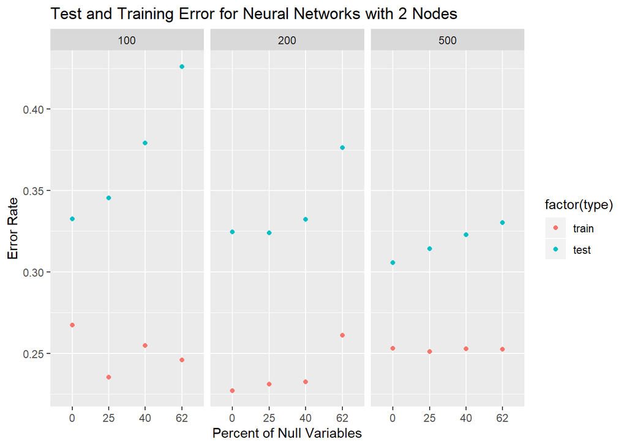

```r
# plot the errors vs null variables for networks trained with 2 nodes
ggplot(results[results$no.nodes == 2,],aes(x=factor(no.nulls),y=error, col=factor(type))) +
  geom_point() +
  labs(title = "Test and Training Error for Neural Networks with 2 Nodes",
       x = "Percent of Null Variables",
       y = "Error Rate") +
  facet_wrap(~train.length) +
  theme(legend.position = "right")
```

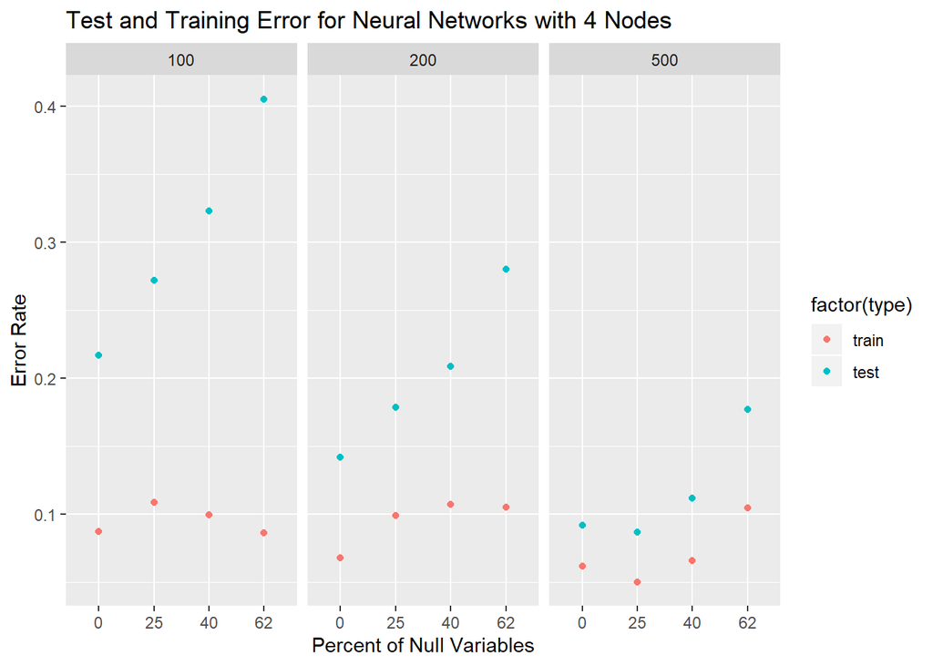

```r
# plot the errors vs null variables for networks trained with 4 nodes
ggplot(results[results$no.nodes == 4,],aes(x=factor(no.nulls),y=error, col=factor(type))) +
  geom_point() +
  labs(title = "Test and Training Error for Neural Networks with 4 Nodes",
       x = "Percent of Null Variables",
       y = "Error Rate") +
  facet_wrap(~train.length) +
  theme(legend.position = "right")
```

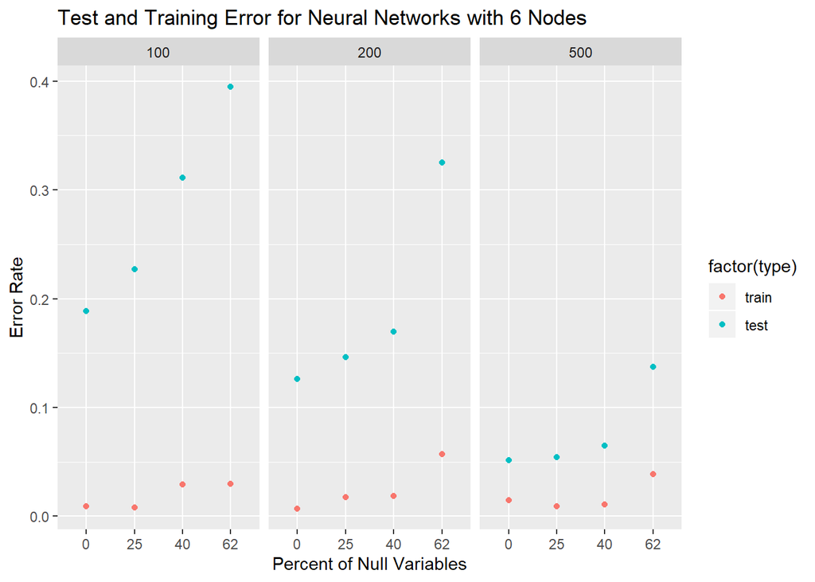

```r
# plot the errors vs null variables for networks trained with 6 nodes
ggplot(results[results$no.nodes == 6,],aes(x=factor(no.nulls),y=error, col=factor(type))) +
  geom_point() +
  labs(title = "Test and Training Error for Neural Networks with 6 Nodes",
       x = "Percent of Null Variables",
       y = "Error Rate") +
  facet_wrap(~train.length) +
  theme(legend.position = "right")
```

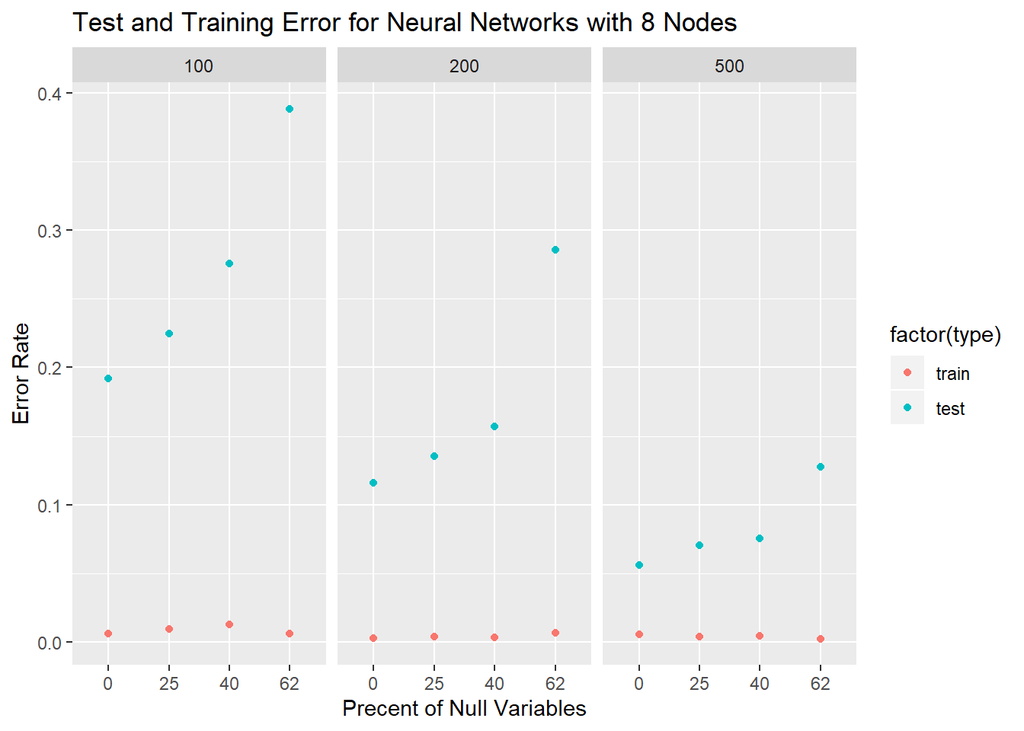

```r
# plot the errors vs null variables for networks trained with 8 nodes
ggplot(results[results$no.nodes == 8,],aes(x=factor(no.nulls),y=error, col=factor(type))) +
  geom_point() +
  labs(title = "Test and Training Error for Neural Networks with 8 Nodes",
       x = "Precent of Null Variables",
       y = "Error Rate") +
  facet_wrap(~train.length) +
  theme(legend.position = "right")
```

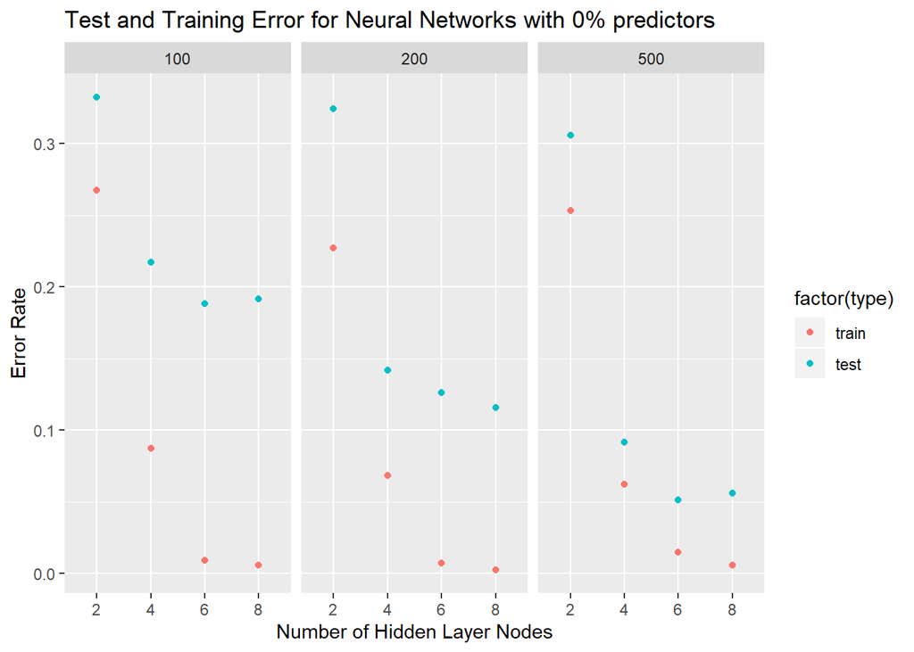

```r
# plot the errors vs null variables for networks trained with 0 null predictors
ggplot(results[results$no.nulls == 0,],aes(x=factor(no.nodes),y=error, col=factor(type))) +
  geom_point() +
  labs(title = "Test and Training Error for Neural Networks with 0% predictors",
       x = "Number of Hidden Layer Nodes",
       y = "Error Rate") +
  facet_wrap(~train.length) +
  theme(legend.position = "right")
```

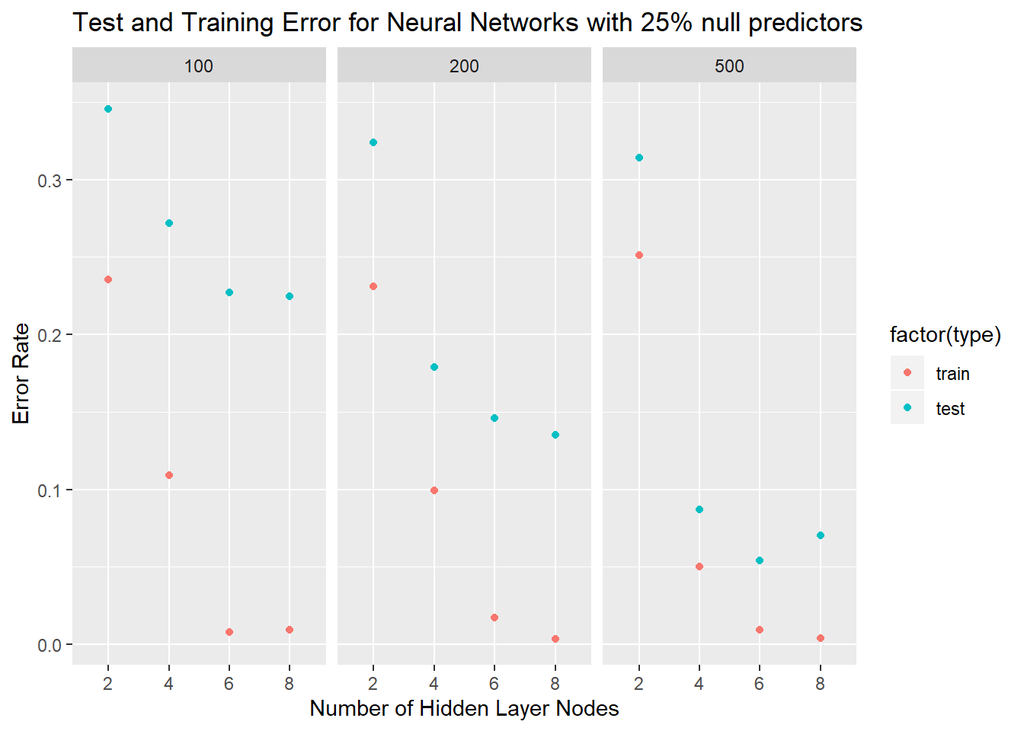

```r
# plot the errors vs null variables for networks trained with 25% null predictors
ggplot(results[results$no.nulls == 25,],aes(x=factor(no.nodes),y=error, col=factor(type))) +
  geom_point() +
  labs(title = "Test and Training Error for Neural Networks with 25% null predictors",
       x = "Number of Hidden Layer Nodes",
       y = "Error Rate") +
  facet_wrap(~train.length) +
  theme(legend.position = "right")
```

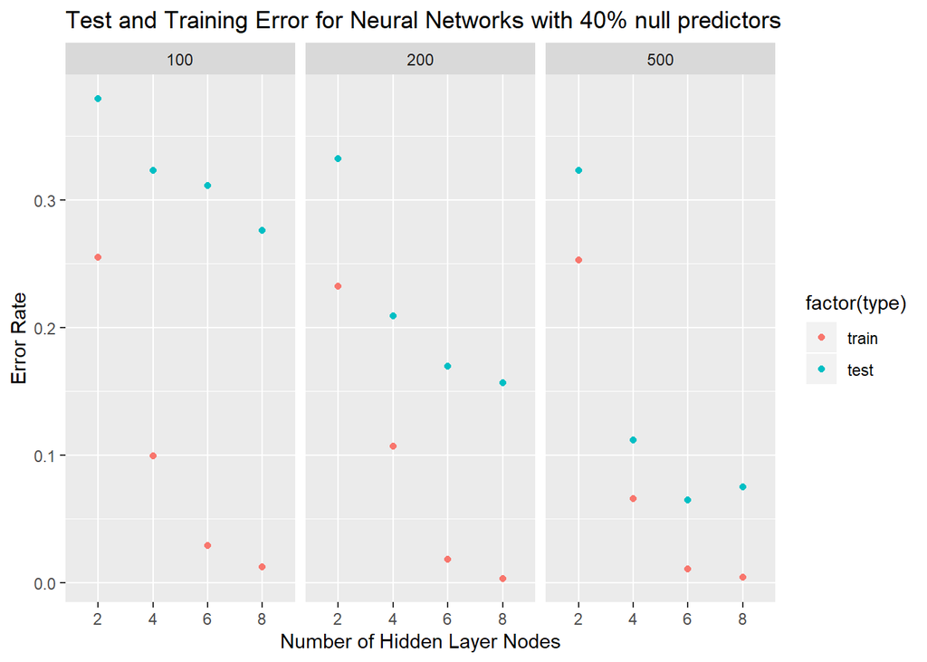

```r
# plot the errors vs null variables for networks trained with 40% null predictors
ggplot(results[results$no.nulls == 40,],aes(x=factor(no.nodes),y=error, col=factor(type))) +
  geom_point() +
  labs(title = "Test and Training Error for Neural Networks with 40% null predictors",
       x = "Number of Hidden Layer Nodes",
       y = "Error Rate") +
  facet_wrap(~train.length) +
  theme(legend.position = "right")
```

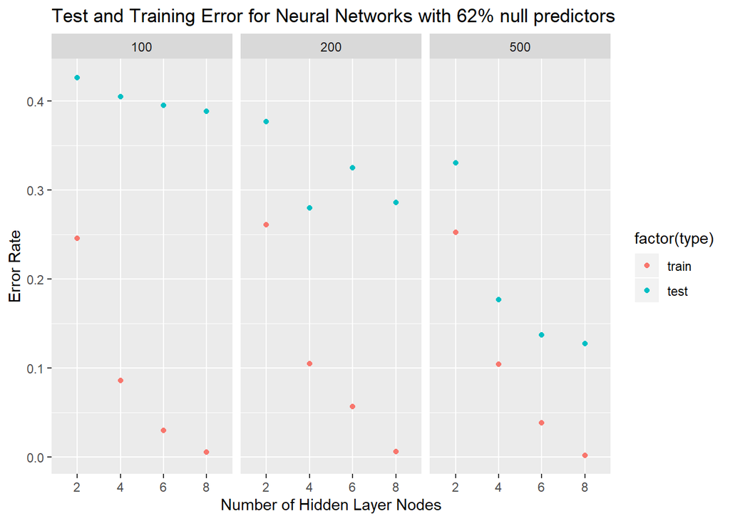

```r
# plot the errors vs null variables for networks trained with 62% null predictors
ggplot(results[results$no.nulls == 62,],aes(x=factor(no.nodes),y=error, col=factor(type))) +
  geom_point() +
  labs(title = "Test and Training Error for Neural Networks with 62% null predictors",
       x = "Number of Hidden Layer Nodes",
       y = "Error Rate") +
  facet_wrap(~train.length) +
  theme(legend.position = "right")
```

```r
# only look at test results because training results could be overfitted
test.results <- results[results$type == "test",]

# sort results from lowest to highest and display the lowest 10 and highest 10
head(test.results[order(test.results$error),],10)
```

```
##    type train.length no.nulls no.nodes      error
## 51 test          500        0        6 0.05140000
## 55 test          500       25        6 0.05418947
## 52 test          500        0        8 0.05598421
## 59 test          500       40        6 0.06472632
## 56 test          500       25        8 0.07052632
## 60 test          500       40        8 0.07514737
## 54 test          500       25        4 0.08682105
## 50 test          500        0        4 0.09181579
## 58 test          500       40        4 0.11179474
## 68 test          200        0        8 0.11577895
```

```r
tail(test.results[order(test.results$error),],10)
```

```
##    type train.length no.nulls no.nodes     error
## 61 test          500       62        2 0.3301579
## 73 test          200       40        2 0.3322421
## 81 test          100        0        2 0.3324526
## 85 test          100       25        2 0.3455895
## 77 test          200       62        2 0.3764789
## 89 test          100       40        2 0.3792632
## 96 test          100       62        8 0.3884316
## 95 test          100       62        6 0.3948421
## 94 test          100       62        4 0.4049737
## 93 test          100       62        2 0.4261579
```

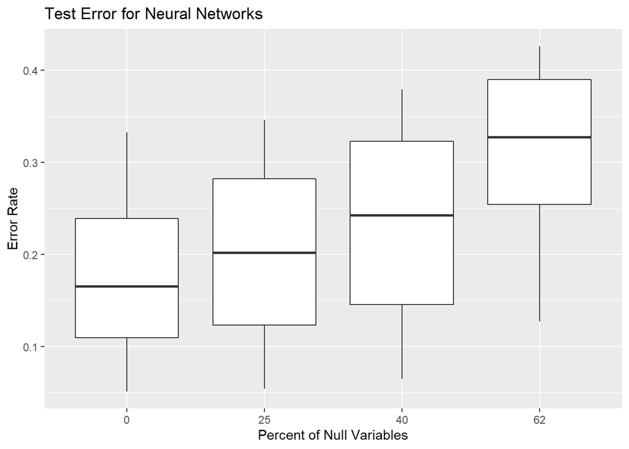

```r
# boxplot the errors vs null variables
ggplot(test.results,aes(x=factor(no.nulls),y=error)) +
  geom_boxplot() +
  labs(title = "Test Error for Neural Networks",
       x = "Percent of Null Variables",
       y = "Error Rate") +
  theme(legend.position = "right")
```

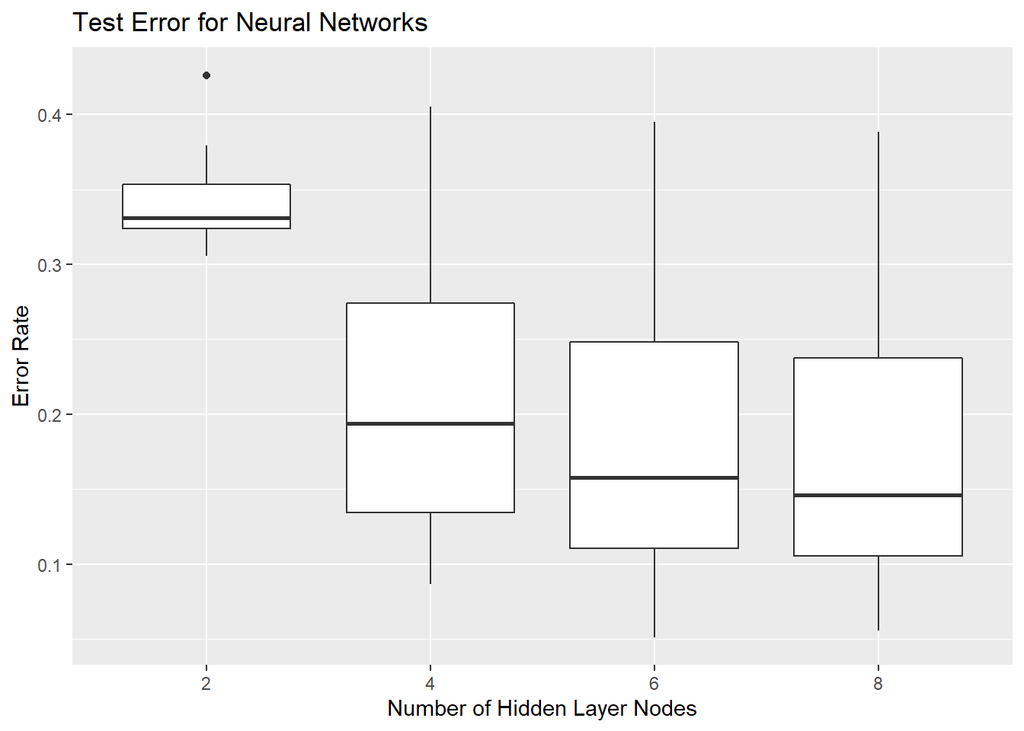

```r
# boxplot the errors vs nodes
ggplot(test.results,aes(x=factor(no.nodes),y=error)) +
  geom_boxplot() +
  labs(title = "Test Error for Neural Networks",
       x = "Number of Hidden Layer Nodes",
       y = "Error Rate") +
  theme(legend.position = "right")
```

[figure not shown]

```r
# boxplot the errors vs data length
ggplot(test.results,aes(x=factor(train.length),y=error)) +
  geom_boxplot() +
  labs(title = "Test Error for Neural Networks",
       x = "Number of Null Variables",
       y = "Error Rate") +
  theme(legend.position = "right")
```

At a high level, we can glean the following from the boxplots of the test error data:

1. The number of null variables is proportional to error rate
2. The number of nodes is inversly proportional to the error rate at what appears to be a logrithmic rate of decay. Less than 4 nodes has a significantly degraded error rate due to the dimensionality of the data. More than 6 nodes can reduce the error slightly but not always. It depends on other factors (such as number of null variables).
3. The increased size of the training data set is inversly proportional to the error rate however even large training data sets can perform worse than small training data sets if the network is not designed correctly with the proper number of nodes for the dimensionality of the data.

At a more granular level the following conclusions were drawn by using the scatterplots:

Regarding the number of null variables:

1. With 0 null variables, a smaller training set and a high number of nodes the model performs decently. This indicates that a higher node count can somewhat overcome a lack of training data.
2. With 0 null variables and a larger number of nodes and data points, the model begins to overfit which can be seen by the diverging test and training error points to the right of the graph.
3. As the number of null variables inceases with relation to the number of covariates, the performance begins to degrade even with a larger number of nodes and larger training data sets. This highlights to importance of data preprocessing.

In summary:

1. A high node count can reduce the affects of limited training data.
2. There is such a thing as too many nodes which can cause overfitting. The dimensionality of the dataset should be proportional to the number of nodes.
3. With zero to 25% null variables in the data set, one node per covariate is sufficient. With a relatively higher percentabe of null variables (40%) 6 nodes was sufficient. When the number of null variables exceeds 50% of all the variables the performance of the model degrade significantly. Preprocessing and preliminary data analysis is important and dropping these null variables before inputting them into the model is beneficial.
4. A larger training set appears to be the most effective tool in lowering the error rate even on a mediocre model.
5. The size of the network, size of the training data set and percentage of null variables have a complex relationship with the model error rate. Fine tuning is required.
6. The best overall performance is with a training data set of size 500, 0 null variables, and 6 nodes which performs at around a 5% error rate.

# 6 Extra 10 points problem: model WiFi localization data

Use `neuralnet` to model the outcome in WiFi localization dataset that we used in previous weeks *using outcome in its original, four-levels format.* Your `neuralnet` models will need to have four output nodes to represent outcome with four levels. Obtain training and test error for this model for several sizes of the hidden layer. Compare resulting test error in predicting Location 3 to that observed for random forest, SVM and KNN approaches earlier in the course.

# Session info

The time it took to knit this file from beginning to end is about (seconds):

```r
proc.time() - ptStart
```

```
##    user  system elapsed
## 2223.28    9.64 2241.68
```